# Causal Infernece: Lab 1

Spring 2026

Xiangyu Song Chanhyuk Park

Washington University in St. Louis

# Introduction

In this lab, we explore fundamental concepts in causal inference: distinguishing between the **Average Treatment Effect (ATE)** and the **Average Treatment Effect on the Treated (ATT)**, and dissecting potential sources of bias in our estimators (particularly **selection bias** and **heterogeneous treatment effects**).

We begin with a **job-training program** example featuring bankers and doctors in a futuristic scenario, then pivot to a more abstract medical example with potential outcomes. Throughout, you’ll see why **random assignment** is so crucial for obtaining unbiased estimates of treatment effects.

## Setup

```r
library(tidyverse)
```

# ATE vs. ATT with Bankers & Doctors

In our futuristic scenario, **bankers** have largely lost their jobs to AI-enhanced ATMs, while **doctors** still have robust employment. We imagine a job-training program that aims to retrain bankers as programmers. However, since doctors aren’t eligible for this program, including them in the overall population can lead to misunderstandings about the **treatment effect** if we simply do a naive difference-in-means. This section highlights:

1. **Why the naive ATE might be misleading** if our treated group (bankers) differs substantially from our control group (a mix of doctors and bankers).
2. **How constructing a control group that resembles the treated group** (bankers only) leads to an estimate closer to the **ATT**—often the real-world quantity of interest.

## 1. Constructing the Population

```r
# Set a seed for reproducibility
set.seed(123)

# Create vectors of doctor salaries ~ U[160, 260] and banker salaries ~ U[43, 64]
doctor <- runif(1000, 160, 260)
bankers <- runif(1000, 43, 64)

# Create a tibble of workers
workers <- tibble(
  job = c(rep('doctor', 1000), rep('banker', 1000)),
  salary = c(doctor, bankers),
  id = 1:2000
)
```

Here, we simulate a population with distinctly different salary distributions for doctors vs. bankers. This difference sets the stage for why we can get a misleading ATE if we ignore pre-existing differences in salary levels.

## 2. Creating Treatment and Control Groups

```r
set.seed(123)

# Draw a sample of 500 bankers to be treated
treated_rows <- sample(1001:2000, size = 500)

# The remaining rows
drop_treats <- workers[-treated_rows,]

# Draw a control sample from the full population (including doctors)
control <- sample_n(drop_treats, size = 500)

# Treatment group
treated <- workers[treated_rows,]
```

Notice that only bankers can receive the treatment, reflecting real-life situations where certain programs are only available to certain subgroups. But our control group is drawn from everyone, including higher-earning doctors. Keep an eye on how this affects our estimated treatment effect.

## 3. Applying the Treatment Effect

```r
# Treatment effect:
#   - If salary < 60, uniform increase between 30-50
#   - If salary >= 60, uniform increase between 0-15
set.seed(123)
treat_eff <- vector()
for(i in 1:nrow(treated)){
  treat_eff <- append(
    treat_eff,
    unlist(
      ifelse(
        treated[i,'salary'] < 60,
        treated[i,'salary'] + runif(1, 30, 50),
        treated[i,'salary'] + runif(1, 0, 15)
      )
    )
  )
}

# Control group salaries remain unchanged
control_sals <- control$salary

# Combine treatment and control into one experimental dataset
exp_group <- bind_rows(treated, control)
exp_group$new_sal <- c(treat_eff, control_sals)
exp_group$treated <- c(rep(1, 500), rep(0, 500))
```

Almost all bankers get the “good” treatment effect (a large salary boost), whereas doctors—if treated—would get only a smaller increase. But because doctors aren’t actually treated, we don’t apply any increase to them here. This sets up a substantial difference in average salaries between doctors in the control group and bankers in the treatment group.

## 4. Exploring the ATE vs. the ATT

```r
# Check the composition of our experimental sample
exp_group %>%
  group_by(job, treated) %>%
  summarise(n = n())
```

[output not shown]

```
## # A tibble: 3 × 3
## # Groups:   job [2]
##   job    treated     n
##   <chr>    <dbl> <int>
## 1 banker       0   169
## 2 banker       1   500
## 3 doctor       0   331
```

```r
# Simple difference-in-means (ATE estimate)
t_res <- t.test(new_sal ~ treated, data = exp_group)
ate <- t_res$estimate[2] - t_res$estimate[1]
ate
```

```
## mean in group 1
##       -67.95963
```

```r
# Explanation of negative estimated ATE
exp_group %>%
  group_by(job, treated) %>%
  summarise(eff_size = mean(new_sal))
```

[output not shown]

```
## # A tibble: 3 × 3
## # Groups:   job [2]
##   job    treated eff_size
##   <chr>    <dbl>    <dbl>
## 1 banker       0     53.0
## 2 banker       1     87.6
## 3 doctor       0    208.
```

```r
exp_group %>%
  group_by(treated) %>%
  summarise(eff_size = mean(new_sal))
```

```
## # A tibble: 2 × 2
##   treated eff_size
##     <dbl>    <dbl>
## 1       0    156.
## 2       1     87.6
```

```r
# Constructing a more appropriate control group (bankers only) for the ATT
control_banker <- workers[-treated_rows,] %>% filter(job == 'banker')
banker_control_sal <- control_banker$salary

exp_group2 <- bind_rows(treated, control_banker)
exp_group2$new_sal <- c(treat_eff, banker_control_sal)
exp_group2$treated <- c(rep(1, 500), rep(0, 500))

t_res2 <- t.test(new_sal ~ treated, data = exp_group2)
att <- t_res2$estimate[2] - t_res2$estimate[1]
att
```

```
## mean in group 1
##        34.33265
```

- We see that the naive ATE is negative, which suggests the training is **hurting** participants on average. However, that’s an artifact of mixing high-salary doctors into the control group.
- Once we limit the control group to bankers only, we get a **positive** effect, which reflects the **ATT** for the subgroup that would actually participate in training.

# Decomposing the Difference in Means

We now switch gears to a smaller-scale **medical scenario** that lets us peek directly into **potential outcomes** (both treatment and control outcomes for each individual). Of course, in real life, we never observe both potential outcomes for the same person; we see only one, making causal inference tricky. This section breaks down how **selection bias** and **heterogeneous treatment effects** each can corrupt naive difference-in-means estimates.

## 1. Setting Up Potential Outcomes for 10 Cancer Patients

```r
po_patients <- tibble(
  patients = c(1:10),
  y_i1 = c(7 , 5, 5, 7, 4, 10, 1, 5, 3, 9),
  y_i0 = c(1, 6, 1, 8, 2, 1, 10, 6, 7, 8),
  po_diff = y_i1 - y_i0
)

po_patients
```

```
## # A tibble: 10 × 4
##    patients  y_i1  y_i0 po_diff
##       <int> <dbl> <dbl>   <dbl>
##  1        1     7     1       6
##  2        2     5     6      -1
##  3        3     5     1       4
##  4        4     7     8      -1
##  5        5     4     2       2
##  6        6    10     1       9
##  7        7     1    10      -9
##  8        8     5     6      -1
##  9        9     3     7      -4
## 10       10     9     8       1
```

```r
# True ATE from potential outcomes
ate <- mean(po_patients$po_diff)
ate
```

```
## [1] 0.6
```

Here, `y_i1` is how many years a patient might live if assigned to an experimental surgery (treatment), and `y_i0` if assigned to chemo (control). We can directly compute the **true ATE** since we artificially see both outcomes for each person. In the real world, we never observe both potential outcomes for the same person.

## 2. Sorting Everyone Into Their Best Outcome (Generating Bias)

```r
po_patients2 <- po_patients %>%
  mutate(
    D = if_else(po_diff >= 0, 1, 0),
    Y = y_i1 * D + y_i0 * (1 - D)
  )

po_patients2
```

```
## # A tibble: 10 × 6
##    patients  y_i1  y_i0 po_diff     D     Y
##       <int> <dbl> <dbl>   <dbl> <dbl> <dbl>
##  1        1     7     1       6     1     7
##  2        2     5     6      -1     0     6
##  3        3     5     1       4     1     5
##  4        4     7     8      -1     0     8
##  5        5     4     2       2     1     4
##  6        6    10     1       9     1    10
##  7        7     1    10      -9     0    10
##  8        8     5     6      -1     0     6
##  9        9     3     7      -4     0     7
## 10       10     9     8       1     1     9
```

```r
# Compute the actual ATT
att <- po_patients2 %>%
  filter(D == 1) %>%
  mutate(tt = Y - y_i0) %>%
  pull(tt) %>%
  mean()

att
```

```
## [1] 4.4
```

```r
# Compute the actual ATC
atc <- po_patients2 %>%
  filter(D == 0) %>%
  mutate(tt = y_i1 - Y) %>%
  pull(tt) %>%
  mean()

atc
```

```
## [1] -3.2
```

By giving everyone the treatment only if it’s beneficial to *them*, we’re introducing strong correlation between potential outcomes and treatment assignment—exactly how **selection bias** arises when sicker (or healthier) patients are more (or less) likely to receive treatment in a real-world setting.

## 3. Estimating Using the Simple Difference in Means

```r
po_patients2 %>%
  group_by(D) %>%
  summarise(diff = mean(Y))
```

```
## # A tibble: 2 × 2
##       D  diff
##   <dbl> <dbl>
## 1     0   7.4
## 2     1   7
```

```r
diff_means <- po_patients2 %>%
  group_by(D) %>%
  summarise(diff = mean(Y)) %>%
  pull(diff) %>%
  diff()

diff_means
```

```
## [1] -0.4
```

```r
ate
```

```
## [1] 0.6
```

## 4. Breaking Down the Bias Components

```r
# Selection bias
s_bias <- po_patients2 %>% filter(D == 1) %>% pull(y_i0) %>% mean() -
  po_patients2 %>% filter(D == 0) %>% pull(Y) %>% mean()

# HTE bias
hte <- nrow(po_patients2 %>% filter(D == 0))/nrow(po_patients2) * (att - atc)

ate + s_bias + hte
```

```
## [1] -0.4
```

```r
diff_means
```

```
## [1] -0.4
```

Here, we see how the difference-in-means **contains** the true ATE *plus* two bias terms:

1. **Selection Bias**: Occurs when treatment assignment is systematically related to potential outcomes.
2. **Heterogeneous Treatment Effects**: If some benefit more than others, and those “better-off” folks are more (or less) likely to be treated, it skews the overall difference-in-means.

# Random Assignment as a Remedy

Randomization aims to break the link between who is treated and which potential outcomes they have, mitigating selection bias and enabling a simpler, more reliable difference-in-means estimation of the treatment effect.

## 1. Random Assignment with 10 Patients (Multiple Reps)

```r
set.seed(123)
dim_est <- vector()

for(i in 1:1000){
  dim_est <-  append(
    dim_est,
    po_patients %>%
      mutate(
        D = rbinom(10, 1, .5),
        Y = y_i1 * D + y_i0 * (1 - D)
      ) %>%
      group_by(D) %>%
      summarise(dim = mean(Y)) %>%
      pull(dim) %>%
      diff()
  )
}

# Average difference-in-means
mean(dim_est)
```

```
## [1] 0.5739345
```

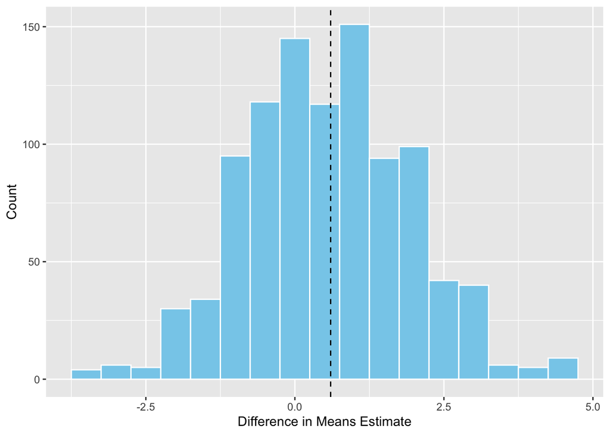

```r
# Distribution of the estimates
ggplot(tibble(d = dim_est), aes(x = d)) +
  geom_histogram(binwidth = 0.5, fill="skyblue", color="white") +
  geom_vline(xintercept = ate, linetype = 'dashed') +
  labs(x = 'Difference in Means Estimate', y = 'Count')
```

```r
# 95% quantiles
quantile(dim_est, c(.025, .975))
```

```
##  2.5% 97.5%
##    -2     3
```

With only 10 patients, random chance can still produce wide variance in the difference-in-means. But **on average** across 1,000 random assignments, the bias cancels out and the mean estimate converges on the true ATE.

## 2. Larger Sample Random Assignment Example (1000 Patients)

```r
set.seed(123)
po_patients_big <- tibble(
  patients = c(1:1000),
  y_i1 = rnorm(1000, .6, .5), # Treatment ~ N(0.6, 0.5^2)
  y_i0 = rnorm(1000, 0, .5),  # Control   ~ N(0,   0.5^2)
  po_diff = y_i1 - y_i0
) %>%
  mutate(
    D = rbinom(1000, 1, .5),
    Y = y_i1 * D + y_i0 * (1 - D)
  )

# True ATE from potential outcomes
ate_big <- mean(po_patients_big$po_diff)
ate_big
```

```
## [1] 0.5868313
```

```r
# ATT and ATC (should be close to ATE in large random sample)
big_att <- po_patients_big %>%
  filter(D == 1) %>%
  mutate(tt = Y - y_i0) %>%
  pull(tt) %>%
  mean()

big_att
```

```
## [1] 0.5788349
```

```r
big_atc <- po_patients_big %>%
  filter(D == 0) %>%
  mutate(tt = y_i1 - Y) %>%
  pull(tt) %>%
  mean()

big_atc
```

```
## [1] 0.5944834
```

```r
# Observed difference in means
big_diff_means <- po_patients_big %>%
  group_by(D) %>%
  summarise(diff = mean(Y)) %>%
  pull(diff) %>%
  diff()

big_diff_means
```

```
## [1] 0.5608872
```

```r
# Check selection and HTE biases
s_bias_big <- po_patients_big %>% filter(D == 1) %>% pull(y_i0) %>% mean() -
  po_patients_big %>% filter(D == 0) %>% pull(Y) %>% mean()

hte_big <- nrow(po_patients_big %>% filter(D == 0))/nrow(po_patients_big) * (big_att - big_atc)

ate_big + s_bias_big + hte_big
```

```
## [1] 0.5608872
```

```r
big_diff_means
```

```
## [1] 0.5608872
```

With 1,000 patients, randomization becomes even more powerful. We see that the **difference in means** closely approximates the **true ATE**, and biases effectively drop to zero.

# Key Takeaways

1. **ATE vs. ATT**: Including individuals who are not actually eligible or never choose treatment (e.g., doctors in our banker example) can produce a misleading **ATE**. Often we care more about the **ATT**—the treatment effect for the subgroup that *would* receive treatment.
2. **Potential Outcomes**: Although we used artificial data to reveal both outcomes per individual, in reality, each person’s counterfactual remains unknown. Causal inference methods are designed to cope with this partial-information challenge.
3. **Bias**:
   - **Selection bias** arises when the likelihood of being treated depends on potential outcomes.
   - **Heterogeneous treatment effects** mean that an “average” effect may mask large differences among subgroups.
4. **Random Assignment**: Underpins credible causal inference because it decouples treatment assignment from individual characteristics, enabling unbiased estimates of the ATE—particularly with sufficiently large samples.